# Trip Generation Analysis - SVC790 Part A

R. Lubega

2026-09-18

# 1 Overview

Dependent variable: `N_trips`. Predictors: `Nr_People_H`, `Elderly`, `Educ_HS`, `Educ_Tertiary`, `Workers_Fulltime`, `Workers_Parttime`, `Learners_students`, `Driv_Lic`.

Every task below is done two ways:

- **Version A - Base R**: uses only functions shipped with base R / the `stats` package (no extra packages, beyond what is unavoidably needed to read the `.xlsx` file in the first place).
- **Version B - Packages**: the same task using a common contributed package that makes it faster or nicer to look at.

Both versions compute the same underlying numbers; only the mechanics differ.

```r
# readxl has no base-R equivalent (base R cannot read .xlsx files), so it is
# loaded once here as shared infrastructure rather than as part of a
# "package version" of any one task.
ensure_pkg("readxl")

if (!dir.exists("figures")) dir.create("figures")
```

## 1.1 Load data

The sheet has a title block in rows 1-9; the real header row is row 10, so we skip the first 9 rows when reading.

```r
xlsx_path <- "RLubega SVC790_Part A_2026.xlsx"

raw <- read_excel(xlsx_path, sheet = "Table 1", skip = 9)

predictors <- c("Nr_People_H", "Elderly", "Educ_HS", "Educ_Tertiary",
                 "Workers_Fulltime", "Workers_Parttime",
                 "Learners_students", "Driv_Lic")

vars <- c("N_trips", predictors)

data <- raw[, vars]
data[] <- lapply(data, function(x) as.numeric(x))

cat("Rows read:", nrow(data), "\n")
```

```
## Rows read: 5387
```

```r
cat("Rows with at least one NA among analysis variables:",
    sum(!complete.cases(data)), "\n")
```

```
## Rows with at least one NA among analysis variables: 71
```

# 2 1. Correlation matrix and plot

The correlation values themselves come from base R `cor()` either way; only the plot differs between the two versions.

```r
cor_mat <- cor(data[, vars], use = "complete.obs")
round(cor_mat, 3)
```

```
##                   N_trips Nr_People_H Elderly Educ_HS Educ_Tertiary
## N_trips             1.000       0.411   0.196   0.240         0.121
## Nr_People_H         0.411       1.000   0.568   0.139         0.026
## Elderly             0.196       0.568   1.000   0.043         0.018
## Educ_HS             0.240       0.139   0.043   1.000        -0.279
## Educ_Tertiary       0.121       0.026   0.018  -0.279         1.000
## Workers_Fulltime    0.230       0.118   0.069   0.252         0.343
## Workers_Parttime    0.142       0.017   0.005   0.044        -0.028
## Learners_students   0.545       0.271   0.135  -0.013        -0.010
## Driv_Lic            0.108       0.017  -0.013   0.074         0.385
## Workers_Fulltime Workers_Parttime Learners_students Driv_Lic
## N_trips 0.230 0.142 0.545 0.108
## Nr_People_H 0.118 0.017 0.271 0.017
## Elderly 0.069 0.005 0.135 -0.013
## Educ_HS 0.252 0.044 -0.013 0.074
## Educ_Tertiary 0.343 -0.028 -0.010 0.385
## Workers_Fulltime 1.000 -0.164 -0.012 0.373
## Workers_Parttime -0.164 1.000 0.025 -0.041
## Learners_students -0.012 0.025 1.000 -0.073
## Driv_Lic 0.373 -0.041 -0.073 1.000
```

## 2.1 Version A - Base R: correlation heatmap (`image()`)

Base R has no built-in ellipse-style correlation plot, so the base-R equivalent here is a colour-coded heatmap built with `image()`, with the correlation values overlaid as text.

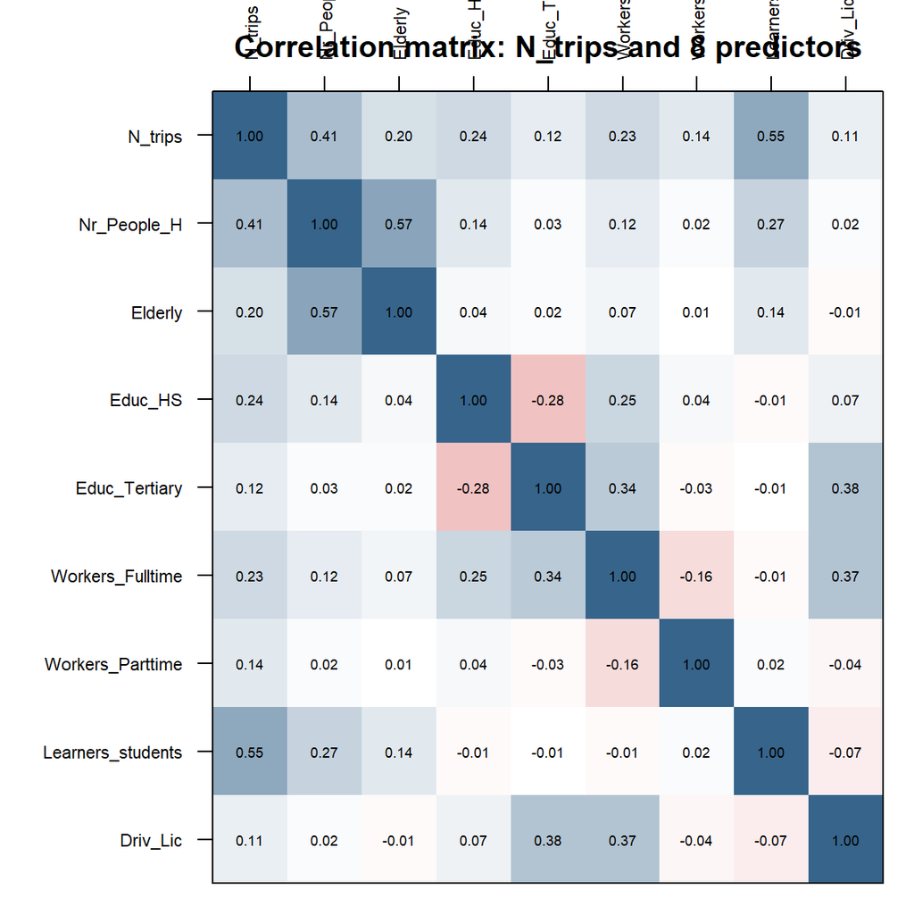

Base R correlation heatmap

```r
plot_cor_heatmap <- function(m, title = "") {
  n <- ncol(m)
  m_flipped <- m[n:1, ]
  op <- par(mar = c(1, 7, 3, 1))
  image(1:n, 1:n, t(m_flipped), axes = FALSE, xlab = "", ylab = "",
        col = colorRampPalette(c("firebrick3", "white", "steelblue4"))(101),
        zlim = c(-1, 1), main = title)
  axis(3, at = 1:n, labels = colnames(m), las = 2, cex.axis = 0.7)
  axis(2, at = 1:n, labels = rev(rownames(m)), las = 2, cex.axis = 0.7)
  for (i in 1:n) {
    for (j in 1:n) text(j, n - i + 1, sprintf("%.2f", m[i, j]), cex = 0.55)
  }
  box()
  par(op)
}

plot_cor_heatmap(cor_mat, "Correlation matrix: N_trips and 8 predictors")
```

## 2.2 Version B - Package (`corrplot`): ellipse plot

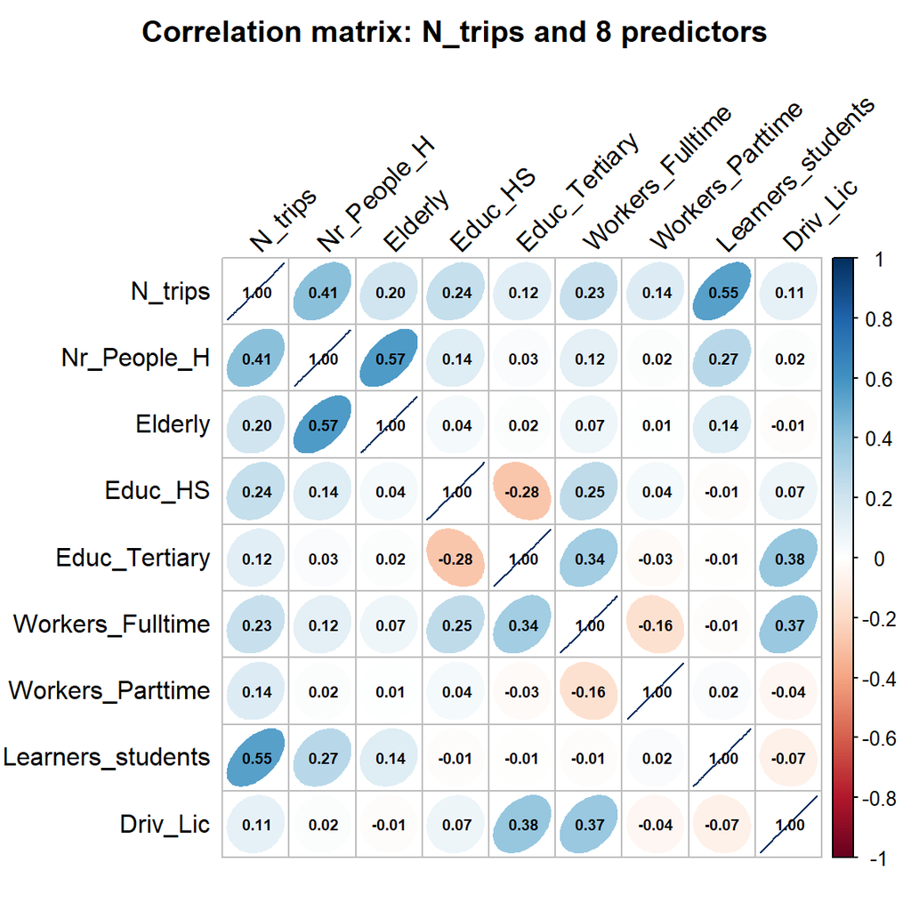

Correlation matrix: N_trips and 8 predictors (corrplot ellipse)

```r
ensure_pkg("corrplot")

corrplot(cor_mat, method = "ellipse", type = "full",
         tl.col = "black", tl.srt = 45,
         addCoef.col = "black", number.cex = 0.6,
         title = "Correlation matrix: N_trips and 8 predictors",
         mar = c(0, 0, 2, 0))
```

# 3 2. Scatterplots of N_trips against each predictor

## 3.1 Version A - Base R

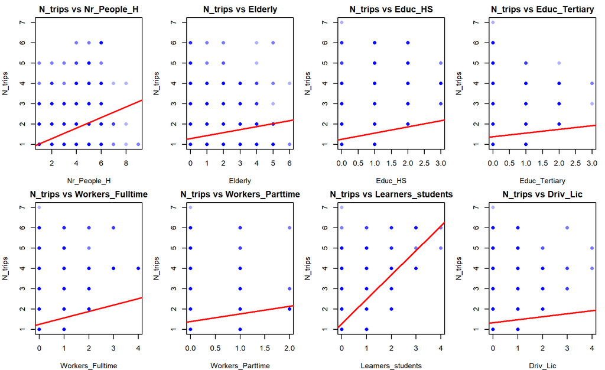

N_trips vs each of the 8 predictors (base R)

```r
plot_scatter_grid <- function() {
  par(mfrow = c(2, 4), mar = c(4, 4, 2, 1))
  for (p in predictors) {
    plot(data[[p]], data[["N_trips"]],
         xlab = p, ylab = "N_trips",
         main = paste("N_trips vs", p),
         pch = 16, col = rgb(0, 0, 1, 0.3))
    abline(lm(data[["N_trips"]] ~ data[[p]]), col = "red", lwd = 2)
  }
}
plot_scatter_grid()
```

## 3.2 Version B - Package (`ggplot2`)

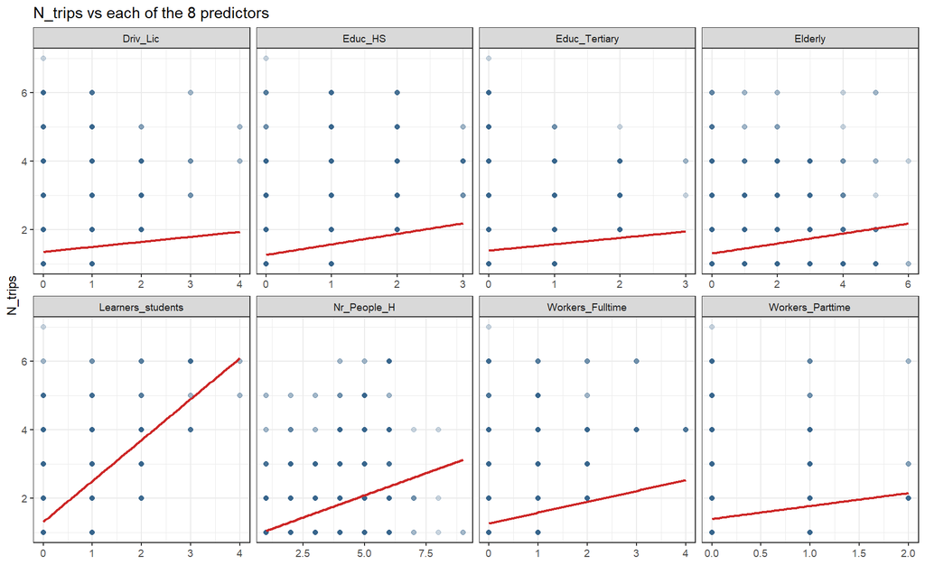

N_trips vs each of the 8 predictors (ggplot2)

```r
ensure_pkg("ggplot2")
ensure_pkg("tidyr")

data_long <- tidyr::pivot_longer(data, cols = all_of(predictors),
                                  names_to = "predictor", values_to = "value")

gg_scatter <- ggplot2::ggplot(data_long, ggplot2::aes(x = value, y = N_trips)) +
  ggplot2::geom_point(alpha = 0.25, colour = "steelblue4") +
  ggplot2::geom_smooth(method = "lm", formula = y ~ x, colour = "firebrick3",
                        se = FALSE, linewidth = 0.8) +
  ggplot2::facet_wrap(~predictor, scales = "free_x", ncol = 4) +
  ggplot2::labs(x = NULL, y = "N_trips",
                title = "N_trips vs each of the 8 predictors") +
  ggplot2::theme_bw(base_size = 9)

gg_scatter
```

# 4 3. Variance Inflation Factors (VIF)

## 4.1 Version A - Base R (manual auxiliary regressions)

Each predictor is regressed on the other 7 using base R `lm()`, and
$$VIF = \frac{1}{1 -
R^2_{aux}}.$$
No `car` package is used for this version.

```r
vif_data <- data[complete.cases(data[, predictors]), predictors]

r2_aux <- sapply(predictors, function(p) {
  other <- setdiff(predictors, p)
  form  <- as.formula(paste(p, "~", paste(other, collapse = " + ")))
  summary(lm(form, data = vif_data))$r.squared
})

vif_table_baseR <- data.frame(Predictor = predictors,
                               R2_aux = round(r2_aux, 4),
                               VIF = round(1 / (1 - r2_aux), 3))

vif_table_baseR_display <- vif_table_baseR
if (knitr::is_latex_output()) {
  vif_table_baseR_display$Predictor <- gsub("_", "\\\\_", vif_table_baseR_display$Predictor)
}
colnames(vif_table_baseR_display) <- c("Predictor", "$R^2_{aux}$", "VIF")

kable_safe(vif_table_baseR_display, row.names = FALSE, escape = FALSE,
             caption = "Base R manual VIF")
```

Base R manual VIF

| Predictor | $R^2_{aux}$ | VIF |
| --- | --- | --- |
| Nr_People_H | 0.3795 | 1.612 |
| Elderly | 0.3253 | 1.482 |
| Educ_HS | 0.2473 | 1.329 |
| Educ_Tertiary | 0.3363 | 1.507 |
| Workers_Fulltime | 0.3151 | 1.460 |
| Workers_Parttime | 0.0407 | 1.042 |
| Learners_students | 0.0829 | 1.090 |
| Driv_Lic | 0.2286 | 1.296 |

## 4.2 Version B - Package (`car::vif()`)

`car::vif()` reads the VIFs off a fitted model object directly.

```r
ensure_pkg("car")

full_formula <- reformulate(predictors, response = "N_trips")
vif_full_model <- lm(full_formula, data = data)

vif_table_car <- data.frame(Predictor = names(car::vif(vif_full_model)),
                             VIF = round(car::vif(vif_full_model), 3))

kable_safe(vif_table_car, row.names = FALSE,
             caption = "car::vif() result")
```

car::vif() result

| Predictor | VIF |
| --- | --- |
| Nr_People_H | 1.612 |
| Elderly | 1.482 |
| Educ_HS | 1.329 |
| Educ_Tertiary | 1.507 |
| Workers_Fulltime | 1.460 |
| Workers_Parttime | 1.042 |
| Learners_students | 1.090 |
| Driv_Lic | 1.296 |

# 5 4. Fit the six models

`lm()` itself is base R either way; what differs between the two versions below is how the fitted models are *reported*.

```r
modelA <- lm(N_trips ~ Nr_People_H, data = data)
modelB <- lm(N_trips ~ Nr_People_H + Driv_Lic, data = data)
modelC <- lm(N_trips ~ Learners_students + Workers_Fulltime + Driv_Lic, data = data)
modelD <- vif_full_model
modelE <- lm(N_trips ~ Nr_People_H + Learners_students + Driv_Lic, data = data)
modelF <- lm(N_trips ~ Nr_People_H + Workers_Fulltime + Learners_students, data = data)

models <- list(A = modelA, B = modelB, C = modelC,
                D = modelD, E = modelE, F = modelF)
```

## 5.1 Version A - Base R: `summary()` printouts

Long lines from `summary()` (e.g. the `Call:`) are manually wrapped at 78 characters before being placed in a fenced block, so nothing runs off the page.

**Model A :** N_trips ~ Nr_People_H

```
Call:
lm(formula = N_trips ~ Nr_People_H, data = data)

Residuals:
    Min      1Q  Median      3Q     Max
-2.1149 -0.2996 -0.0403  0.1817  4.1817

Coefficients:
            Estimate Std. Error t value Pr(>|t|)
(Intercept) 0.780985   0.019963   39.12   <2e-16 ***
Nr_People_H 0.259329   0.007157   36.24   <2e-16 ***
---
Signif. codes:  0 '***' 0.001 '**' 0.01 '*' 0.05 '.' 0.1 ' ' 1

Residual standard error: 0.6959 on 5380 degrees of freedom
  (5 observations deleted due to missingness)
Multiple R-squared:  0.1962,    Adjusted R-squared:  0.196
F-statistic:  1313 on 1 and 5380 DF,  p-value: < 2.2e-16
```

**Model B :** N_trips ~ Nr_People_H + Driv_Lic

```
Call:
lm(formula = N_trips ~ Nr_People_H + Driv_Lic, data = data)

Residuals:
    Min      1Q  Median      3Q     Max
-2.0341 -0.3621 -0.1043  0.2475  4.2549

Coefficients:
            Estimate Std. Error t value Pr(>|t|)
(Intercept) 0.713830   0.021370   33.40   <2e-16 ***
Nr_People_H 0.257808   0.007113   36.25   <2e-16 ***
Driv_Lic    0.132613   0.015713    8.44   <2e-16 ***
---
Signif. codes:  0 '***' 0.001 '**' 0.01 '*' 0.05 '.' 0.1 ' ' 1

Residual standard error: 0.6914 on 5379 degrees of freedom
  (5 observations deleted due to missingness)
Multiple R-squared:  0.2067,    Adjusted R-squared:  0.2064
F-statistic: 700.7 on 2 and 5379 DF,  p-value: < 2.2e-16
```

**Model C :** N_trips ~ Learners_students + Workers_Fulltime + Driv_Lic

```
Call:
lm(formula = N_trips ~ Learners_students + Workers_Fulltime +
    Driv_Lic, data = data)

Residuals:
    Min      1Q  Median      3Q     Max
-1.5201 -0.3902 -0.1098  0.2392  5.8902

Coefficients:
                  Estimate Std. Error t value Pr(>|t|)
(Intercept)        1.10984    0.01214  91.428  < 2e-16 ***
Learners_students  1.20513    0.02110  57.122  < 2e-16 ***
Workers_Fulltime   0.28037    0.01475  19.013  < 2e-16 ***
Driv_Lic           0.09025    0.01481   6.095 1.17e-09 ***
---
Signif. codes:  0 '***' 0.001 '**' 0.01 '*' 0.05 '.' 0.1 ' ' 1

Residual standard error: 0.6022 on 5383 degrees of freedom
Multiple R-squared:  0.4141,    Adjusted R-squared:  0.4138
F-statistic:  1268 on 3 and 5383 DF,  p-value: < 2.2e-16
```

**Model D :** N_trips ~ Nr_People_H + Elderly + Educ_HS + Educ_Tertiary + Workers_Fulltime + Workers_Parttime + Learners_students + Driv_Lic

```
Call:
lm(formula = full_formula, data = data)

Residuals:
    Min      1Q  Median      3Q     Max
-1.4694 -0.3225 -0.0975  0.1641  4.3515

Coefficients:
                   Estimate Std. Error t value Pr(>|t|)
(Intercept)        0.706093   0.016793  42.048   <2e-16 ***
Nr_People_H        0.129836   0.006671  19.464   <2e-16 ***
Elderly           -0.021507   0.008972  -2.397   0.0166 *
Educ_HS            0.233347   0.012779  18.260   <2e-16 ***
Educ_Tertiary      0.187435   0.018083  10.365   <2e-16 ***
Workers_Fulltime   0.144875   0.014090  10.282   <2e-16 ***
Workers_Parttime   0.336228   0.024048  13.982   <2e-16 ***
Learners_students  0.984266   0.020920  47.049   <2e-16 ***
Driv_Lic           0.040696   0.013166   3.091   0.0020 **
---
Signif. codes:  0 '***' 0.001 '**' 0.01 '*' 0.05 '.' 0.1 ' ' 1

Residual standard error: 0.4992 on 5307 degrees of freedom
  (71 observations deleted due to missingness)
Multiple R-squared:  0.4781,    Adjusted R-squared:  0.4773
F-statistic: 607.8 on 8 and 5307 DF,  p-value: < 2.2e-16
```

**Model E :** N_trips ~ Nr_People_H + Learners_students + Driv_Lic

```
Call:
lm(formula = N_trips ~ Nr_People_H + Learners_students + Driv_Lic,
    data = data)

Residuals:
    Min      1Q  Median      3Q     Max
-1.8759 -0.3244 -0.1441  0.1873  4.3676

Coefficients:
                  Estimate Std. Error t value Pr(>|t|)
(Intercept)       0.818586   0.017927   45.66   <2e-16 ***
Nr_People_H       0.162760   0.006236   26.10   <2e-16 ***
Learners_students 1.040378   0.021337   48.76   <2e-16 ***
Driv_Lic          0.180322   0.013123   13.74   <2e-16 ***
---
Signif. codes:  0 '***' 0.001 '**' 0.01 '*' 0.05 '.' 0.1 ' ' 1

Residual standard error: 0.5758 on 5378 degrees of freedom
  (5 observations deleted due to missingness)
Multiple R-squared:  0.4499,    Adjusted R-squared:  0.4496
F-statistic:  1466 on 3 and 5378 DF,  p-value: < 2.2e-16
```

**Model F :** N_trips ~ Nr_People_H + Workers_Fulltime + Learners_students

```
Call:
lm(formula = N_trips ~ Nr_People_H + Workers_Fulltime + Learners_students,
    data = data)

Residuals:
    Min      1Q  Median      3Q     Max
-1.7753 -0.3801 -0.1084  0.1744  4.4461

Coefficients:
                  Estimate Std. Error t value Pr(>|t|)
(Intercept)       0.811424   0.016976   47.80   <2e-16 ***
Nr_People_H       0.148495   0.006153   24.14   <2e-16 ***
Workers_Fulltime  0.271651   0.012889   21.08   <2e-16 ***
Learners_students 1.036471   0.020824   49.77   <2e-16 ***
---
Signif. codes:  0 '***' 0.001 '**' 0.01 '*' 0.05 '.' 0.1 ' ' 1

Residual standard error: 0.563 on 5378 degrees of freedom
  (5 observations deleted due to missingness)
Multiple R-squared:  0.474, Adjusted R-squared:  0.4737
F-statistic:  1615 on 3 and 5378 DF,  p-value: < 2.2e-16
```

## 5.2 Version B - Package (`broom`): tidy coefficient and fit tables

```r
ensure_pkg("broom")

for (nm in names(models)) {
  tidy_tbl <- broom::tidy(models[[nm]])
  needspace(nrow(tidy_tbl) + 10)
  cat("**Model", nm, ":**", deparse(formula(models[[nm]])), "\n\n")
  tidy_tbl[ , -1] <- round(tidy_tbl[ , -1], 4)
  print(kable_safe(tidy_tbl, row.names = FALSE))
  cat("\n")
  glance_tbl <- broom::glance(models[[nm]])[c("r.squared", "adj.r.squared",
                                               "statistic", "p.value", "nobs")]
  glance_tbl <- round(glance_tbl, 4)
  colnames(glance_tbl) <- c("$R^2$", "$R^2_{adj}$", "statistic", "p.value", "nobs")
  print(kable_safe(glance_tbl, row.names = FALSE, escape = FALSE))
  cat("\n\n")
}
```

**Model A :** N_trips ~ Nr_People_H

| term | estimate | std.error | statistic | p.value |
| --- | --- | --- | --- | --- |
| (Intercept) | 0.7810 | 0.0200 | 39.1219 | 0 |
| Nr_People_H | 0.2593 | 0.0072 | 36.2368 | 0 |

| $R^2$ | $R^2_{adj}$ | statistic | p.value | nobs |
| --- | --- | --- | --- | --- |
| 0.1962 | 0.196 | 1313.108 | 0 | 5382 |

**Model B :** N_trips ~ Nr_People_H + Driv_Lic

| term | estimate | std.error | statistic | p.value |
| --- | --- | --- | --- | --- |
| (Intercept) | 0.7138 | 0.0214 | 33.4026 | 0 |
| Nr_People_H | 0.2578 | 0.0071 | 36.2469 | 0 |
| Driv_Lic | 0.1326 | 0.0157 | 8.4395 | 0 |

| $R^2$ | $R^2_{adj}$ | statistic | p.value | nobs |
| --- | --- | --- | --- | --- |
| 0.2067 | 0.2064 | 700.7369 | 0 | 5382 |

**Model C :** N_trips ~ Learners_students + Workers_Fulltime + Driv_Lic

| term | estimate | std.error | statistic | p.value |
| --- | --- | --- | --- | --- |
| (Intercept) | 1.1098 | 0.0121 | 91.4284 | 0 |
| Learners_students | 1.2051 | 0.0211 | 57.1224 | 0 |
| Workers_Fulltime | 0.2804 | 0.0147 | 19.0127 | 0 |
| Driv_Lic | 0.0902 | 0.0148 | 6.0951 | 0 |

| $R^2$ | $R^2_{adj}$ | statistic | p.value | nobs |
| --- | --- | --- | --- | --- |
| 0.4141 | 0.4138 | 1268.247 | 0 | 5387 |

**Model D :** N_trips ~ Nr_People_H + Elderly + Educ_HS + Educ_Tertiary + Workers_Fulltime + Workers_Parttime + Learners_students + Driv_Lic

| term | estimate | std.error | statistic | p.value |
| --- | --- | --- | --- | --- |
| (Intercept) | 0.7061 | 0.0168 | 42.0480 | 0.0000 |
| Nr_People_H | 0.1298 | 0.0067 | 19.4641 | 0.0000 |
| Elderly | -0.0215 | 0.0090 | -2.3972 | 0.0166 |
| Educ_HS | 0.2333 | 0.0128 | 18.2600 | 0.0000 |
| Educ_Tertiary | 0.1874 | 0.0181 | 10.3653 | 0.0000 |
| Workers_Fulltime | 0.1449 | 0.0141 | 10.2822 | 0.0000 |
| Workers_Parttime | 0.3362 | 0.0240 | 13.9815 | 0.0000 |
| Learners_students | 0.9843 | 0.0209 | 47.0492 | 0.0000 |
| Driv_Lic | 0.0407 | 0.0132 | 3.0911 | 0.0020 |

| $R^2$ | $R^2_{adj}$ | statistic | p.value | nobs |
| --- | --- | --- | --- | --- |
| 0.4781 | 0.4773 | 607.7632 | 0 | 5316 |

**Model E :** N_trips ~ Nr_People_H + Learners_students + Driv_Lic

| term | estimate | std.error | statistic | p.value |
| --- | --- | --- | --- | --- |
| (Intercept) | 0.8186 | 0.0179 | 45.6624 | 0 |
| Nr_People_H | 0.1628 | 0.0062 | 26.1003 | 0 |
| Learners_students | 1.0404 | 0.0213 | 48.7583 | 0 |
| Driv_Lic | 0.1803 | 0.0131 | 13.7411 | 0 |

| $R^2$ | $R^2_{adj}$ | statistic | p.value | nobs |
| --- | --- | --- | --- | --- |
| 0.4499 | 0.4496 | 1465.998 | 0 | 5382 |

**Model F :** N_trips ~ Nr_People_H + Workers_Fulltime + Learners_students

| term | estimate | std.error | statistic | p.value |
| --- | --- | --- | --- | --- |
| (Intercept) | 0.8114 | 0.0170 | 47.7995 | 0 |
| Nr_People_H | 0.1485 | 0.0062 | 24.1355 | 0 |
| Workers_Fulltime | 0.2717 | 0.0129 | 21.0755 | 0 |
| Learners_students | 1.0365 | 0.0208 | 49.7738 | 0 |

| $R^2$ | $R^2_{adj}$ | statistic | p.value | nobs |
| --- | --- | --- | --- | --- |
| 0.474 | 0.4737 | 1615.479 | 0 | 5382 |

# 6 5. Model comparison and parsimony discussion

The full predictor list per model is long for Model D, so - to keep every table column comfortably inside the page margins - it is listed once here as plain text (which wraps like any other paragraph) rather than repeated inside a table cell.

- **A**: N_trips ~ Nr_People_H
- **B**: N_trips ~ Nr_People_H + Driv_Lic
- **C**: N_trips ~ Learners_students + Workers_Fulltime + Driv_Lic
- **D**: N_trips ~ Nr_People_H + Elderly + Educ_HS + Educ_Tertiary + Workers_Fulltime + Workers_Parttime + Learners_students + Driv_Lic
- **E**: N_trips ~ Nr_People_H + Learners_students + Driv_Lic
- **F**: N_trips ~ Nr_People_H + Workers_Fulltime + Learners_students

## 6.1 Version A - Base R comparison table

```r
comparison <- data.frame(
  Model = names(models),
  Predictors = sapply(models, get_predictor_str),
  R2 = sapply(models, function(m) round(summary(m)$r.squared, 4)),
  Adj_R2 = sapply(models, function(m) round(summary(m)$adj.r.squared, 4)),
  n = sapply(models, function(m) nobs(m)),
  stringsAsFactors = FALSE
)

write.csv(comparison, "model_comparison.csv", row.names = FALSE)

comparison_display <- comparison[, c("Model", "R2", "Adj_R2", "n")]
colnames(comparison_display) <- c("Model", "$R^2$", "$R^2_{adj}$", "n")

kable_safe(comparison_display, row.names = FALSE, escape = FALSE,
             caption = "Base R model comparison table (see predictor list above)")
```

Base R model comparison table (see predictor list above)

| Model | $R^2$ | $R^2_{adj}$ | n |
| --- | --- | --- | --- |
| A | 0.1962 | 0.1960 | 5382 |
| B | 0.2067 | 0.2064 | 5382 |
| C | 0.4141 | 0.4138 | 5387 |
| D | 0.4781 | 0.4773 | 5316 |
| E | 0.4499 | 0.4496 | 5382 |
| F | 0.4740 | 0.4737 | 5382 |

## 6.2 Version B - Package (`broom` + `dplyr`) comparison table

```r
ensure_pkg("dplyr")
ensure_pkg("purrr")

comparison_broom <- purrr::map_dfr(names(models), function(nm) {
  g <- broom::glance(models[[nm]])
  dplyr::tibble(Model = nm,
                Predictors = get_predictor_str(models[[nm]]),
                R2 = round(g$r.squared, 4),
                Adj_R2 = round(g$adj.r.squared, 4),
                n = g$nobs)
})

comparison_broom_display <- comparison_broom[, c("Model", "R2", "Adj_R2", "n")]
colnames(comparison_broom_display) <- c("Model", "$R^2$", "$R^2_{adj}$", "n")

kable_safe(comparison_broom_display, row.names = FALSE, escape = FALSE,
             caption = "broom/dplyr model comparison table (see predictor list above)")
```

broom/dplyr model comparison table (see predictor list above)

| Model | $R^2$ | $R^2_{adj}$ | n |
| --- | --- | --- | --- |
| A | 0.1962 | 0.1960 | 5382 |
| B | 0.2067 | 0.2064 | 5382 |
| C | 0.4141 | 0.4138 | 5387 |
| D | 0.4781 | 0.4773 | 5316 |
| E | 0.4499 | 0.4496 | 5382 |
| F | 0.4740 | 0.4737 | 5382 |

### 6.2.1 Coefficient significance

```r
sig_flags <- function(m) {
  cf <- summary(m)$coefficients
  cf <- cf[rownames(cf) != "(Intercept)", , drop = FALSE]
  data.frame(term = rownames(cf),
             t = round(cf[, "t value"], 2),
             p = round(cf[, "Pr(>|t|)"], 4),
             sig = cf[, "Pr(>|t|)"] < 0.05)
}

for (nm in names(models)) {
  flags <- sig_flags(models[[nm]])
  needspace(nrow(flags) + 8)
  cat("**Model", nm, "**\n\n")
  print(kable_safe(flags, row.names = FALSE))
  cat("\n\n")
}
```

**Model A**

| term | t | p | sig |
| --- | --- | --- | --- |
| Nr_People_H | 36.24 | 0 | TRUE |

**Model B**

| term | t | p | sig |
| --- | --- | --- | --- |
| Nr_People_H | 36.25 | 0 | TRUE |
| Driv_Lic | 8.44 | 0 | TRUE |

**Model C**

| term | t | p | sig |
| --- | --- | --- | --- |
| Learners_students | 57.12 | 0 | TRUE |
| Workers_Fulltime | 19.01 | 0 | TRUE |
| Driv_Lic | 6.10 | 0 | TRUE |

**Model D**

| term | t | p | sig |
| --- | --- | --- | --- |
| Nr_People_H | 19.46 | 0.0000 | TRUE |
| Elderly | -2.40 | 0.0166 | TRUE |
| Educ_HS | 18.26 | 0.0000 | TRUE |
| Educ_Tertiary | 10.37 | 0.0000 | TRUE |
| Workers_Fulltime | 10.28 | 0.0000 | TRUE |
| Workers_Parttime | 13.98 | 0.0000 | TRUE |
| Learners_students | 47.05 | 0.0000 | TRUE |
| Driv_Lic | 3.09 | 0.0020 | TRUE |

**Model E**

| term | t | p | sig |
| --- | --- | --- | --- |
| Nr_People_H | 26.10 | 0 | TRUE |
| Learners_students | 48.76 | 0 | TRUE |
| Driv_Lic | 13.74 | 0 | TRUE |

**Model F**

| term | t | p | sig |
| --- | --- | --- | --- |
| Nr_People_H | 24.14 | 0 | TRUE |
| Workers_Fulltime | 21.08 | 0 | TRUE |
| Learners_students | 49.77 | 0 | TRUE |

### 6.2.2 Parsimony commentary

The commentary below is computed directly from the fitted results above (not hard-coded), so it stays accurate if the underlying data changes.

Model A (single predictor Nr_People_H) already explains $R^2$ = 0.196 ($R^2_{adj}$ = 0.196).

Among the reduced (non-D) models, Model F achieves the highest $R^2_{adj}$ (0.474) using only 3 predictor(s): Nr_People_H + Workers_Fulltime + Learners_students.

Model D (all 8 predictors) reaches $R^2_{adj}$ = 0.477 – a gain of just 0.0036 over Model F, for 5 extra predictors.

Manual VIFs for all 8 predictors are below 2 (max is 1.612), so multicollinearity is not severe enough on its own to destabilise Model D’s coefficients – all 8 coefficients in Model D remain statistically significant at the 5% level. However, several of the predictors are moderately correlated with each other (e.g. Nr_People_H-Elderly, Educ_Tertiary-Driv_Lic, Educ_Tertiary-Workers_Fulltime), so part of what they add in Model D duplicates explanatory power already captured by the core predictors (Nr_People_H, Learners_students, Workers_Fulltime, Driv_Lic).

Given that Model F recovers 99.2% of Model D’s $R^2_{adj}$ with 5 fewer predictors, the marginal explanatory gain from fitting the full 8-predictor Model D does not appear to be worth its loss of parsimony: a small, well-chosen predictor set (household size, learners/students, workers, driver’s licence holding) captures almost all of the explanatory power at much lower risk of overfitting and unnecessary collinearity.

# 7 Outputs

Outputs written to the working directory:

- `figures/correlation_heatmap_baseR.png`
- `figures/correlation_ellipse.png`
- `figures/scatterplots_baseR.png`
- `figures/scatterplots_ggplot.png`
- `model_comparison.csv`

# 8 S0 Scenario

## 8.1 Trip Generation (Forecast Year 2035)

```r
zone <- 1:8
hhs25 <- c(5470, 1400, 7340, 2500, 5800, 9900, 550, 7550)
jobs25 <- c(1160, 1800, 6500, 25240, 5990, 2000, 12700, 2500)
g_hh <- c(2.1, 2.5, 3.2, 3.2, 3.2, 2.5, 2.1, 4.2) / 100
g_jobs <- c(1.5, 1.9, 2.0, 2.4, 2.0, 2.0, 3.5, 2.0) / 100
nr_people <- c(1.5, 2.5, 2.2, 3.6, 2.2, 3.2, 1.5, 3.6)
workers_ft <- c(1.1, 0.52, 0.46, 0.95, 0.46, 0.79, 0.31, 0.95)
learners <- c(0.35, 0.1, 0.09, 0.15, 0.09, 0.13, 0.06, 0.15)

rate <- 0.811424 + 0.148495*nr_people + 0.271651*workers_ft + 1.036471*learners
hhs35 <- hhs25 * (1 + g_hh)^10
jobs35 <- jobs25 * (1 + g_jobs)^10

P25 <- rate * hhs25
P35 <- rate * hhs35
scale35 <- sum(P35) / sum(jobs35)
A35 <- jobs35 * scale35

result <- data.frame(zone, hhs35 = round(hhs35,1), jobs35 = round(jobs35,1),
                      P35 = round(P35,1), A35 = round(A35,1),
                      P35_peak = round(P35*0.4,1), A35_peak = round(A35*0.4,1))
print(result)
```

```
##   zone   hhs35  jobs35     P35     A35 P35_peak A35_peak
## 1    1  6733.6  1346.2 11418.4  1561.6   4567.4    624.7
## 2    2  1792.1  2172.8  2558.4  2520.4   1023.3   1008.2
## 3    3 10057.6  7923.5 13641.6  9191.3   5456.7   3676.5
## 4    4  3425.6 31995.5  6027.5 37115.0   2411.0  14846.0
## 5    5  7947.4  7301.8 10779.5  8470.1   4311.8   3388.0
## 6    6 12672.8  2438.0 20732.2  2828.1   8292.9   1131.2
## 7    7   677.0 17914.6   799.3 20781.1    319.7   8312.4
## 8    8 11392.6  3047.5 20045.9  3535.1   8018.3   1414.0
```

```r
cat("Base 24h P total:", sum(P25), "\n")
```

```
## Base 24h P total: 63625.51
```

```r
cat("2035 24h P total:", sum(P35), sprintf(" (%.2f%% growth)\n", (sum(P35)/sum(P25)-1)*100))
```

```
## 2035 24h P total: 86002.74  (35.17% growth)
```

```r
cat("2035 peak P = A total:", sum(P35*0.4), "\n")
```

```
## 2035 peak P = A total: 34401.1
```